# Risk Factor Analysis

## Outcome Variable

**Outcome Variable:** ever_stunted

## Predictor Variables

**Intervention Variable:** mhtcm

**Adjustment Set:**

- arm
- W_mage
- meducyrs
- feducyrs
- single
- delta_W_mage
- delta_meducyrs
- delta_feducyrs
- delta_single

## Stratifying Variables

The analysis was stratified on these variable(s):

- agecat
- studyid
- country

## Data Summary

| agecat | studyid | country | mhtcm | ever_stunted | n_cell | n |
| --- | --- | --- | --- | --- | --- | --- |
| 0-6 months | ki0047075b-MAL-ED | BANGLADESH | >=160 | 0 | 4 | 254 |
| 0-6 months | ki0047075b-MAL-ED | BANGLADESH | >=160 | 1 | 0 | 254 |
| 0-6 months | ki0047075b-MAL-ED | BANGLADESH | <145 | 0 | 42 | 254 |
| 0-6 months | ki0047075b-MAL-ED | BANGLADESH | <145 | 1 | 14 | 254 |
| 0-6 months | ki0047075b-MAL-ED | BANGLADESH | [145-150) | 0 | 74 | 254 |
| 0-6 months | ki0047075b-MAL-ED | BANGLADESH | [145-150) | 1 | 17 | 254 |
| 0-6 months | ki0047075b-MAL-ED | BANGLADESH | [150-155) | 0 | 73 | 254 |
| 0-6 months | ki0047075b-MAL-ED | BANGLADESH | [150-155) | 1 | 9 | 254 |
| 0-6 months | ki0047075b-MAL-ED | BANGLADESH | [155-160) | 0 | 18 | 254 |
| 0-6 months | ki0047075b-MAL-ED | BANGLADESH | [155-160) | 1 | 3 | 254 |
| 0-6 months | ki0047075b-MAL-ED | BRAZIL | >=160 | 0 | 63 | 222 |
| 0-6 months | ki0047075b-MAL-ED | BRAZIL | >=160 | 1 | 5 | 222 |
| 0-6 months | ki0047075b-MAL-ED | BRAZIL | <145 | 0 | 7 | 222 |
| 0-6 months | ki0047075b-MAL-ED | BRAZIL | <145 | 1 | 1 | 222 |
| 0-6 months | ki0047075b-MAL-ED | BRAZIL | [145-150) | 0 | 27 | 222 |
| 0-6 months | ki0047075b-MAL-ED | BRAZIL | [145-150) | 1 | 6 | 222 |
| 0-6 months | ki0047075b-MAL-ED | BRAZIL | [150-155) | 0 | 47 | 222 |
| 0-6 months | ki0047075b-MAL-ED | BRAZIL | [150-155) | 1 | 4 | 222 |
| 0-6 months | ki0047075b-MAL-ED | BRAZIL | [155-160) | 0 | 55 | 222 |
| 0-6 months | ki0047075b-MAL-ED | BRAZIL | [155-160) | 1 | 7 | 222 |
| 0-6 months | ki0047075b-MAL-ED | INDIA | >=160 | 0 | 13 | 242 |
| 0-6 months | ki0047075b-MAL-ED | INDIA | >=160 | 1 | 1 | 242 |
| 0-6 months | ki0047075b-MAL-ED | INDIA | <145 | 0 | 25 | 242 |
| 0-6 months | ki0047075b-MAL-ED | INDIA | <145 | 1 | 4 | 242 |
| 0-6 months | ki0047075b-MAL-ED | INDIA | [145-150) | 0 | 55 | 242 |
| 0-6 months | ki0047075b-MAL-ED | INDIA | [145-150) | 1 | 15 | 242 |
| 0-6 months | ki0047075b-MAL-ED | INDIA | [150-155) | 0 | 70 | 242 |
| 0-6 months | ki0047075b-MAL-ED | INDIA | [150-155) | 1 | 18 | 242 |
| 0-6 months | ki0047075b-MAL-ED | INDIA | [155-160) | 0 | 38 | 242 |
| 0-6 months | ki0047075b-MAL-ED | INDIA | [155-160) | 1 | 3 | 242 |

[output cut: 643 more lines]

The following strata were considered:

- agecat: 0-24 months, studyid: ki0047075b-MAL-ED, country: BANGLADESH
- agecat: 0-24 months, studyid: ki0047075b-MAL-ED, country: BRAZIL
- agecat: 0-24 months, studyid: ki0047075b-MAL-ED, country: INDIA
- agecat: 0-24 months, studyid: ki0047075b-MAL-ED, country: NEPAL
- agecat: 0-24 months, studyid: ki0047075b-MAL-ED, country: PERU
- agecat: 0-24 months, studyid: ki0047075b-MAL-ED, country: SOUTH AFRICA
- agecat: 0-24 months, studyid: ki0047075b-MAL-ED, country: TANZANIA, UNITED REPUBLIC OF
- agecat: 0-24 months, studyid: ki1000304b-SAS-CompFeed, country: INDIA
- agecat: 0-24 months, studyid: ki1000304b-SAS-FoodSuppl, country: INDIA
- agecat: 0-24 months, studyid: ki1017093-NIH-Birth, country: BANGLADESH
- agecat: 0-24 months, studyid: ki1017093b-PROVIDE, country: BANGLADESH
- agecat: 0-24 months, studyid: ki1017093c-NIH-Crypto, country: BANGLADESH
- agecat: 0-24 months, studyid: ki1066203-TanzaniaChild2, country: TANZANIA, UNITED REPUBLIC OF
- agecat: 0-24 months, studyid: ki1101329-Keneba, country: GAMBIA
- agecat: 0-24 months, studyid: ki1112895-Guatemala BSC, country: GUATEMALA
- agecat: 0-24 months, studyid: ki1112895-iLiNS-Zinc, country: BURKINA FASO
- agecat: 0-24 months, studyid: ki1119695-PROBIT, country: BELARUS
- agecat: 0-24 months, studyid: ki1126311-ZVITAMBO, country: ZIMBABWE
- agecat: 0-24 months, studyid: ki1135781-COHORTS, country: GUATEMALA
- agecat: 0-24 months, studyid: ki1135781-COHORTS, country: INDIA
- agecat: 0-24 months, studyid: ki1135781-COHORTS, country: PHILIPPINES
- agecat: 0-24 months, studyid: ki1148112-LCNI-5, country: MALAWI
- agecat: 0-24 months, studyid: kiGH5241-JiVitA-3, country: BANGLADESH
- agecat: 0-6 months, studyid: ki0047075b-MAL-ED, country: BANGLADESH
- agecat: 0-6 months, studyid: ki0047075b-MAL-ED, country: BRAZIL
- agecat: 0-6 months, studyid: ki0047075b-MAL-ED, country: INDIA
- agecat: 0-6 months, studyid: ki0047075b-MAL-ED, country: NEPAL
- agecat: 0-6 months, studyid: ki0047075b-MAL-ED, country: PERU
- agecat: 0-6 months, studyid: ki0047075b-MAL-ED, country: SOUTH AFRICA
- agecat: 0-6 months, studyid: ki0047075b-MAL-ED, country: TANZANIA, UNITED REPUBLIC OF
- agecat: 0-6 months, studyid: ki1000304b-SAS-CompFeed, country: INDIA
- agecat: 0-6 months, studyid: ki1000304b-SAS-FoodSuppl, country: INDIA
- agecat: 0-6 months, studyid: ki1017093-NIH-Birth, country: BANGLADESH
- agecat: 0-6 months, studyid: ki1017093b-PROVIDE, country: BANGLADESH
- agecat: 0-6 months, studyid: ki1017093c-NIH-Crypto, country: BANGLADESH
- agecat: 0-6 months, studyid: ki1066203-TanzaniaChild2, country: TANZANIA, UNITED REPUBLIC OF
- agecat: 0-6 months, studyid: ki1101329-Keneba, country: GAMBIA
- agecat: 0-6 months, studyid: ki1112895-Guatemala BSC, country: GUATEMALA
- agecat: 0-6 months, studyid: ki1119695-PROBIT, country: BELARUS
- agecat: 0-6 months, studyid: ki1126311-ZVITAMBO, country: ZIMBABWE
- agecat: 0-6 months, studyid: ki1135781-COHORTS, country: GUATEMALA
- agecat: 0-6 months, studyid: ki1135781-COHORTS, country: INDIA
- agecat: 0-6 months, studyid: ki1135781-COHORTS, country: PHILIPPINES
- agecat: 0-6 months, studyid: ki1148112-LCNI-5, country: MALAWI
- agecat: 0-6 months, studyid: kiGH5241-JiVitA-3, country: BANGLADESH
- agecat: 6-24 months, studyid: ki0047075b-MAL-ED, country: BANGLADESH
- agecat: 6-24 months, studyid: ki0047075b-MAL-ED, country: BRAZIL
- agecat: 6-24 months, studyid: ki0047075b-MAL-ED, country: INDIA
- agecat: 6-24 months, studyid: ki0047075b-MAL-ED, country: NEPAL
- agecat: 6-24 months, studyid: ki0047075b-MAL-ED, country: PERU
- agecat: 6-24 months, studyid: ki0047075b-MAL-ED, country: SOUTH AFRICA
- agecat: 6-24 months, studyid: ki0047075b-MAL-ED, country: TANZANIA, UNITED REPUBLIC OF
- agecat: 6-24 months, studyid: ki1000304b-SAS-CompFeed, country: INDIA
- agecat: 6-24 months, studyid: ki1000304b-SAS-FoodSuppl, country: INDIA
- agecat: 6-24 months, studyid: ki1017093-NIH-Birth, country: BANGLADESH
- agecat: 6-24 months, studyid: ki1017093b-PROVIDE, country: BANGLADESH
- agecat: 6-24 months, studyid: ki1017093c-NIH-Crypto, country: BANGLADESH
- agecat: 6-24 months, studyid: ki1066203-TanzaniaChild2, country: TANZANIA, UNITED REPUBLIC OF
- agecat: 6-24 months, studyid: ki1101329-Keneba, country: GAMBIA
- agecat: 6-24 months, studyid: ki1112895-Guatemala BSC, country: GUATEMALA
- agecat: 6-24 months, studyid: ki1112895-iLiNS-Zinc, country: BURKINA FASO
- agecat: 6-24 months, studyid: ki1119695-PROBIT, country: BELARUS
- agecat: 6-24 months, studyid: ki1126311-ZVITAMBO, country: ZIMBABWE
- agecat: 6-24 months, studyid: ki1135781-COHORTS, country: GUATEMALA
- agecat: 6-24 months, studyid: ki1135781-COHORTS, country: INDIA
- agecat: 6-24 months, studyid: ki1135781-COHORTS, country: PHILIPPINES
- agecat: 6-24 months, studyid: ki1148112-LCNI-5, country: MALAWI
- agecat: 6-24 months, studyid: kiGH5241-JiVitA-3, country: BANGLADESH

### Dropped Strata

Some strata were dropped due to rare outcomes:

- agecat: 0-6 months, studyid: ki0047075b-MAL-ED, country: BANGLADESH
- agecat: 0-6 months, studyid: ki0047075b-MAL-ED, country: BRAZIL
- agecat: 0-6 months, studyid: ki0047075b-MAL-ED, country: INDIA
- agecat: 0-6 months, studyid: ki0047075b-MAL-ED, country: NEPAL
- agecat: 0-6 months, studyid: ki0047075b-MAL-ED, country: PERU
- agecat: 0-6 months, studyid: ki0047075b-MAL-ED, country: SOUTH AFRICA
- agecat: 0-6 months, studyid: ki0047075b-MAL-ED, country: TANZANIA, UNITED REPUBLIC OF
- agecat: 0-6 months, studyid: ki1000304b-SAS-FoodSuppl, country: INDIA
- agecat: 0-6 months, studyid: ki1017093-NIH-Birth, country: BANGLADESH
- agecat: 0-6 months, studyid: ki1017093b-PROVIDE, country: BANGLADESH
- agecat: 0-6 months, studyid: ki1017093c-NIH-Crypto, country: BANGLADESH
- agecat: 0-6 months, studyid: ki1066203-TanzaniaChild2, country: TANZANIA, UNITED REPUBLIC OF
- agecat: 0-6 months, studyid: ki1101329-Keneba, country: GAMBIA
- agecat: 0-6 months, studyid: ki1112895-Guatemala BSC, country: GUATEMALA
- agecat: 0-6 months, studyid: ki1119695-PROBIT, country: BELARUS
- agecat: 0-6 months, studyid: ki1135781-COHORTS, country: GUATEMALA
- agecat: 0-6 months, studyid: ki1135781-COHORTS, country: PHILIPPINES
- agecat: 0-6 months, studyid: ki1148112-LCNI-5, country: MALAWI
- agecat: 6-24 months, studyid: ki0047075b-MAL-ED, country: BANGLADESH
- agecat: 6-24 months, studyid: ki0047075b-MAL-ED, country: BRAZIL
- agecat: 6-24 months, studyid: ki0047075b-MAL-ED, country: INDIA
- agecat: 6-24 months, studyid: ki0047075b-MAL-ED, country: NEPAL
- agecat: 6-24 months, studyid: ki0047075b-MAL-ED, country: PERU
- agecat: 6-24 months, studyid: ki0047075b-MAL-ED, country: SOUTH AFRICA
- agecat: 6-24 months, studyid: ki0047075b-MAL-ED, country: TANZANIA, UNITED REPUBLIC OF
- agecat: 6-24 months, studyid: ki1000304b-SAS-FoodSuppl, country: INDIA
- agecat: 6-24 months, studyid: ki1017093-NIH-Birth, country: BANGLADESH
- agecat: 6-24 months, studyid: ki1017093b-PROVIDE, country: BANGLADESH
- agecat: 6-24 months, studyid: ki1017093c-NIH-Crypto, country: BANGLADESH
- agecat: 6-24 months, studyid: ki1101329-Keneba, country: GAMBIA
- agecat: 6-24 months, studyid: ki1112895-Guatemala BSC, country: GUATEMALA
- agecat: 6-24 months, studyid: ki1119695-PROBIT, country: BELARUS
- agecat: 6-24 months, studyid: ki1148112-LCNI-5, country: MALAWI
- agecat: 0-24 months, studyid: ki0047075b-MAL-ED, country: BANGLADESH
- agecat: 0-24 months, studyid: ki0047075b-MAL-ED, country: BRAZIL
- agecat: 0-24 months, studyid: ki0047075b-MAL-ED, country: INDIA
- agecat: 0-24 months, studyid: ki0047075b-MAL-ED, country: NEPAL
- agecat: 0-24 months, studyid: ki0047075b-MAL-ED, country: SOUTH AFRICA
- agecat: 0-24 months, studyid: ki0047075b-MAL-ED, country: TANZANIA, UNITED REPUBLIC OF
- agecat: 0-24 months, studyid: ki1017093-NIH-Birth, country: BANGLADESH
- agecat: 0-24 months, studyid: ki1017093c-NIH-Crypto, country: BANGLADESH
- agecat: 0-24 months, studyid: ki1101329-Keneba, country: GAMBIA
- agecat: 0-24 months, studyid: ki1112895-Guatemala BSC, country: GUATEMALA
- agecat: 0-24 months, studyid: ki1112895-iLiNS-Zinc, country: BURKINA FASO
- agecat: 0-24 months, studyid: ki1119695-PROBIT, country: BELARUS
- agecat: 0-24 months, studyid: ki1148112-LCNI-5, country: MALAWI

## Methods Detail

We’re interested in the causal parameters $E[Y_a]$ for all values of $a \in \mathcal{A}$. These parameters represent the mean outcome if, possibly contrary to fact, we intervened to set all units to have $A=a$. Under the randomization and positivity assumptions, these are identified by the statistical parameters $\psi_a=E_W[E_{Y|A,W}(Y|A=a,W)]$. In addition, we’re interested in the mean of $Y$, $E[Y]$ under no intervention (the observed mean). We will estimate these parameters by using SuperLearner to fit the relevant likelihood factors – $E_{Y|A,W}(Y|A=a,W)$ and $p(A=a|W)$, and then updating our likelihood fit using a joint TMLE.

For unadjusted analyses ($W=\{\}$), initial likelihoods were estimated using Lrnr_glm to estimate the simple $E(Y|A)$ and Lrnr_mean to estimate $p(A)$. For adjusted analyses, a small library containing Lrnr_glmnet, Lrnr_xgboost, and Lrnr_mean was used.

Having estimated these parameters, we will then use the delta method to estimate relative risks and attributable risks relative to a prespecified baseline level of $A$.

[output not shown]

```
##            ever_stunted
## mhtcm         0
##   >=160     136
##   <145      116
##   [145-150) 392
##   [150-155) 531
##   [155-160) 360
```

# Results Detail

## Results Plots

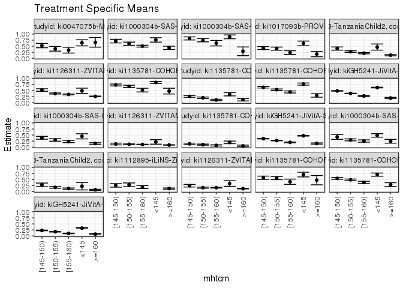

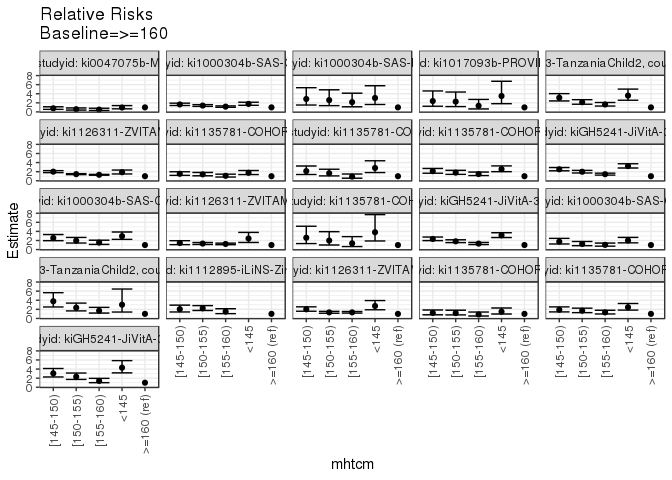

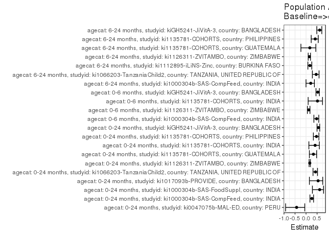

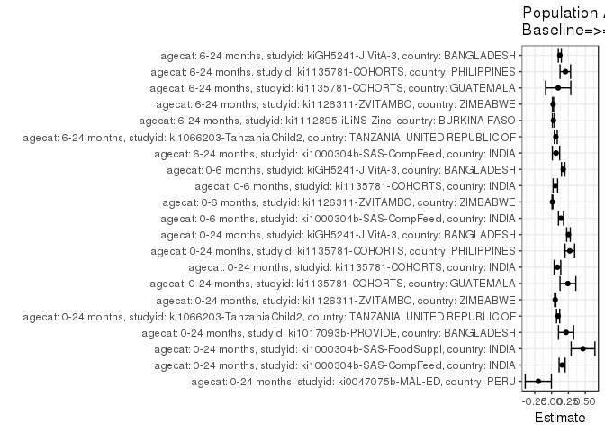

## Results Table

### Parameter: TSM

| agecat | studyid | country | intervention_level | baseline_level | estimate | ci_lower | ci_upper |
| --- | --- | --- | --- | --- | --- | --- | --- |
| 0-24 months | ki0047075b-MAL-ED | PERU | >=160 | NA | 0.6594694 | 0.4611345 | 0.8578042 |
| 0-24 months | ki0047075b-MAL-ED | PERU | <145 | NA | 0.6408872 | 0.5138973 | 0.7678770 |
| 0-24 months | ki0047075b-MAL-ED | PERU | [145-150) | NA | 0.5259621 | 0.4363176 | 0.6156066 |
| 0-24 months | ki0047075b-MAL-ED | PERU | [150-155) | NA | 0.3944372 | 0.2987633 | 0.4901111 |
| 0-24 months | ki0047075b-MAL-ED | PERU | [155-160) | NA | 0.3370615 | 0.2156174 | 0.4585056 |
| 0-24 months | ki1000304b-SAS-CompFeed | INDIA | >=160 | NA | 0.4319654 | 0.3631632 | 0.5007676 |
| 0-24 months | ki1000304b-SAS-CompFeed | INDIA | <145 | NA | 0.7605297 | 0.6699771 | 0.8510822 |
| 0-24 months | ki1000304b-SAS-CompFeed | INDIA | [145-150) | NA | 0.7112534 | 0.6354844 | 0.7870224 |
| 0-24 months | ki1000304b-SAS-CompFeed | INDIA | [150-155) | NA | 0.6041165 | 0.5371623 | 0.6710708 |
| 0-24 months | ki1000304b-SAS-CompFeed | INDIA | [155-160) | NA | 0.5021280 | 0.4639737 | 0.5402824 |
| 0-24 months | ki1000304b-SAS-FoodSuppl | INDIA | >=160 | NA | 0.2894734 | 0.1087205 | 0.4702263 |
| 0-24 months | ki1000304b-SAS-FoodSuppl | INDIA | <145 | NA | 0.8880613 | 0.8088318 | 0.9672908 |
| 0-24 months | ki1000304b-SAS-FoodSuppl | INDIA | [145-150) | NA | 0.8231479 | 0.7588087 | 0.8874871 |
| 0-24 months | ki1000304b-SAS-FoodSuppl | INDIA | [150-155) | NA | 0.7502909 | 0.6809802 | 0.8196015 |
| 0-24 months | ki1000304b-SAS-FoodSuppl | INDIA | [155-160) | NA | 0.6244702 | 0.5126392 | 0.7363012 |
| 0-24 months | ki1017093b-PROVIDE | BANGLADESH | >=160 | NA | 0.1760540 | 0.0639787 | 0.2881294 |
| 0-24 months | ki1017093b-PROVIDE | BANGLADESH | <145 | NA | 0.6164769 | 0.5200711 | 0.7128826 |
| 0-24 months | ki1017093b-PROVIDE | BANGLADESH | [145-150) | NA | 0.4221925 | 0.3599167 | 0.4844682 |
| 0-24 months | ki1017093b-PROVIDE | BANGLADESH | [150-155) | NA | 0.3991671 | 0.3341428 | 0.4641914 |
| 0-24 months | ki1017093b-PROVIDE | BANGLADESH | [155-160) | NA | 0.2369791 | 0.1606191 | 0.3133391 |
| 0-24 months | ki1066203-TanzaniaChild2 | TANZANIA, UNITED REPUBLIC OF | >=160 | NA | 0.1293675 | 0.1042179 | 0.1545171 |
| 0-24 months | ki1066203-TanzaniaChild2 | TANZANIA, UNITED REPUBLIC OF | <145 | NA | 0.4645013 | 0.3374178 | 0.5915847 |
| 0-24 months | ki1066203-TanzaniaChild2 | TANZANIA, UNITED REPUBLIC OF | [145-150) | NA | 0.4033668 | 0.3367097 | 0.4700239 |
| 0-24 months | ki1066203-TanzaniaChild2 | TANZANIA, UNITED REPUBLIC OF | [150-155) | NA | 0.2763419 | 0.2422587 | 0.3104250 |
| 0-24 months | ki1066203-TanzaniaChild2 | TANZANIA, UNITED REPUBLIC OF | [155-160) | NA | 0.2122792 | 0.1843408 | 0.2402177 |
| 0-24 months | ki1126311-ZVITAMBO | ZIMBABWE | >=160 | NA | 0.2625510 | 0.2503022 | 0.2747997 |
| 0-24 months | ki1126311-ZVITAMBO | ZIMBABWE | <145 | NA | 0.4922906 | 0.3825433 | 0.6020379 |
| 0-24 months | ki1126311-ZVITAMBO | ZIMBABWE | [145-150) | NA | 0.5242787 | 0.4719771 | 0.5765804 |
| 0-24 months | ki1126311-ZVITAMBO | ZIMBABWE | [150-155) | NA | 0.3814622 | 0.3580855 | 0.4048390 |
| 0-24 months | ki1126311-ZVITAMBO | ZIMBABWE | [155-160) | NA | 0.3439985 | 0.3268362 | 0.3611608 |

[output cut: 74 more lines]

### Parameter: E(Y)

| agecat | studyid | country | intervention_level | baseline_level | estimate | ci_lower | ci_upper |
| --- | --- | --- | --- | --- | --- | --- | --- |
| 0-24 months | ki0047075b-MAL-ED | PERU | NA | NA | 0.4620690 | 0.4045891 | 0.5195488 |
| 0-24 months | ki1000304b-SAS-CompFeed | INDIA | NA | NA | 0.5877754 | 0.5430036 | 0.6325472 |
| 0-24 months | ki1000304b-SAS-FoodSuppl | INDIA | NA | NA | 0.7555012 | 0.7137976 | 0.7972049 |
| 0-24 months | ki1017093b-PROVIDE | BANGLADESH | NA | NA | 0.3901345 | 0.3531446 | 0.4271245 |
| 0-24 months | ki1066203-TanzaniaChild2 | TANZANIA, UNITED REPUBLIC OF | NA | NA | 0.2259432 | 0.2090636 | 0.2428228 |
| 0-24 months | ki1126311-ZVITAMBO | ZIMBABWE | NA | NA | 0.3157734 | 0.3065944 | 0.3249525 |
| 0-24 months | ki1135781-COHORTS | GUATEMALA | NA | NA | 0.7221362 | 0.6977013 | 0.7465711 |
| 0-24 months | ki1135781-COHORTS | INDIA | NA | NA | 0.2109129 | 0.1925934 | 0.2292325 |
| 0-24 months | ki1135781-COHORTS | PHILIPPINES | NA | NA | 0.5716154 | 0.5540738 | 0.5891570 |
| 0-24 months | kiGH5241-JiVitA-3 | BANGLADESH | NA | NA | 0.4439035 | 0.4363886 | 0.4514185 |
| 0-6 months | ki1000304b-SAS-CompFeed | INDIA | NA | NA | 0.2905983 | 0.2613336 | 0.3198630 |
| 0-6 months | ki1126311-ZVITAMBO | ZIMBABWE | NA | NA | 0.1014228 | 0.0954577 | 0.1073879 |
| 0-6 months | ki1135781-COHORTS | INDIA | NA | NA | 0.1073718 | 0.0933439 | 0.1213997 |
| 0-6 months | kiGH5241-JiVitA-3 | BANGLADESH | NA | NA | 0.3217983 | 0.3150446 | 0.3285520 |
| 6-24 months | ki1000304b-SAS-CompFeed | INDIA | NA | NA | 0.3087401 | 0.2746057 | 0.3428745 |
| 6-24 months | ki1066203-TanzaniaChild2 | TANZANIA, UNITED REPUBLIC OF | NA | NA | 0.1357889 | 0.1200421 | 0.1515357 |
| 6-24 months | ki1112895-iLiNS-Zinc | BURKINA FASO | NA | NA | 0.1520334 | 0.1259980 | 0.1780689 |
| 6-24 months | ki1126311-ZVITAMBO | ZIMBABWE | NA | NA | 0.1426075 | 0.1346615 | 0.1505536 |
| 6-24 months | ki1135781-COHORTS | GUATEMALA | NA | NA | 0.5690516 | 0.5294273 | 0.6086758 |
| 6-24 months | ki1135781-COHORTS | PHILIPPINES | NA | NA | 0.4901079 | 0.4693271 | 0.5108888 |
| 6-24 months | kiGH5241-JiVitA-3 | BANGLADESH | NA | NA | 0.1971650 | 0.1890838 | 0.2052463 |

### Parameter: RR

| agecat | studyid | country | intervention_level | baseline_level | estimate | ci_lower | ci_upper |
| --- | --- | --- | --- | --- | --- | --- | --- |
| 0-24 months | ki0047075b-MAL-ED | PERU | >=160 | >=160 | 1.0000000 | 1.0000000 | 1.0000000 |
| 0-24 months | ki0047075b-MAL-ED | PERU | <145 | >=160 | 0.9718225 | 0.6778385 | 1.3933096 |
| 0-24 months | ki0047075b-MAL-ED | PERU | [145-150) | >=160 | 0.7975535 | 0.5654963 | 1.1248376 |
| 0-24 months | ki0047075b-MAL-ED | PERU | [150-155) | >=160 | 0.5981130 | 0.4073711 | 0.8781652 |
| 0-24 months | ki0047075b-MAL-ED | PERU | [155-160) | >=160 | 0.5111102 | 0.3197377 | 0.8170246 |
| 0-24 months | ki1000304b-SAS-CompFeed | INDIA | >=160 | >=160 | 1.0000000 | 1.0000000 | 1.0000000 |
| 0-24 months | ki1000304b-SAS-CompFeed | INDIA | <145 | >=160 | 1.7606263 | 1.4560617 | 2.1288968 |
| 0-24 months | ki1000304b-SAS-CompFeed | INDIA | [145-150) | >=160 | 1.6465517 | 1.4096822 | 1.9232225 |
| 0-24 months | ki1000304b-SAS-CompFeed | INDIA | [150-155) | >=160 | 1.3985298 | 1.2206690 | 1.6023063 |
| 0-24 months | ki1000304b-SAS-CompFeed | INDIA | [155-160) | >=160 | 1.1624265 | 1.0218574 | 1.3223326 |
| 0-24 months | ki1000304b-SAS-FoodSuppl | INDIA | >=160 | >=160 | 1.0000000 | 1.0000000 | 1.0000000 |
| 0-24 months | ki1000304b-SAS-FoodSuppl | INDIA | <145 | >=160 | 3.0678512 | 1.6329043 | 5.7637860 |
| 0-24 months | ki1000304b-SAS-FoodSuppl | INDIA | [145-150) | >=160 | 2.8436045 | 1.5162549 | 5.3329338 |
| 0-24 months | ki1000304b-SAS-FoodSuppl | INDIA | [150-155) | >=160 | 2.5919164 | 1.3802424 | 4.8672834 |
| 0-24 months | ki1000304b-SAS-FoodSuppl | INDIA | [155-160) | >=160 | 2.1572628 | 1.1295109 | 4.1201752 |
| 0-24 months | ki1017093b-PROVIDE | BANGLADESH | >=160 | >=160 | 1.0000000 | 1.0000000 | 1.0000000 |
| 0-24 months | ki1017093b-PROVIDE | BANGLADESH | <145 | >=160 | 3.5016342 | 1.8179982 | 6.7444744 |
| 0-24 months | ki1017093b-PROVIDE | BANGLADESH | [145-150) | >=160 | 2.3980846 | 1.2477290 | 4.6090212 |
| 0-24 months | ki1017093b-PROVIDE | BANGLADESH | [150-155) | >=160 | 2.2672988 | 1.1750634 | 4.3747796 |
| 0-24 months | ki1017093b-PROVIDE | BANGLADESH | [155-160) | >=160 | 1.3460591 | 0.6593638 | 2.7479139 |
| 0-24 months | ki1066203-TanzaniaChild2 | TANZANIA, UNITED REPUBLIC OF | >=160 | >=160 | 1.0000000 | 1.0000000 | 1.0000000 |
| 0-24 months | ki1066203-TanzaniaChild2 | TANZANIA, UNITED REPUBLIC OF | <145 | >=160 | 3.5905561 | 2.5669957 | 5.0222496 |
| 0-24 months | ki1066203-TanzaniaChild2 | TANZANIA, UNITED REPUBLIC OF | [145-150) | >=160 | 3.1179920 | 2.4160502 | 4.0238707 |
| 0-24 months | ki1066203-TanzaniaChild2 | TANZANIA, UNITED REPUBLIC OF | [150-155) | >=160 | 2.1360995 | 1.6968955 | 2.6889819 |
| 0-24 months | ki1066203-TanzaniaChild2 | TANZANIA, UNITED REPUBLIC OF | [155-160) | >=160 | 1.6409006 | 1.2976919 | 2.0748799 |
| 0-24 months | ki1126311-ZVITAMBO | ZIMBABWE | >=160 | >=160 | 1.0000000 | 1.0000000 | 1.0000000 |
| 0-24 months | ki1126311-ZVITAMBO | ZIMBABWE | <145 | >=160 | 1.8750287 | 1.4931330 | 2.3546012 |
| 0-24 months | ki1126311-ZVITAMBO | ZIMBABWE | [145-150) | >=160 | 1.9968645 | 1.7887093 | 2.2292430 |
| 0-24 months | ki1126311-ZVITAMBO | ZIMBABWE | [150-155) | >=160 | 1.4529073 | 1.3452622 | 1.5691660 |
| 0-24 months | ki1126311-ZVITAMBO | ZIMBABWE | [155-160) | >=160 | 1.3102161 | 1.2237986 | 1.4027358 |

[output cut: 74 more lines]

### Parameter: PAR

| agecat | studyid | country | intervention_level | baseline_level | estimate | ci_lower | ci_upper |
| --- | --- | --- | --- | --- | --- | --- | --- |
| 0-24 months | ki0047075b-MAL-ED | PERU | >=160 | NA | -0.1974004 | -0.3915880 | -0.0032128 |
| 0-24 months | ki1000304b-SAS-CompFeed | INDIA | >=160 | NA | 0.1558100 | 0.1113248 | 0.2002952 |
| 0-24 months | ki1000304b-SAS-FoodSuppl | INDIA | >=160 | NA | 0.4660278 | 0.2897438 | 0.6423118 |
| 0-24 months | ki1017093b-PROVIDE | BANGLADESH | >=160 | NA | 0.2140805 | 0.1019263 | 0.3262347 |
| 0-24 months | ki1066203-TanzaniaChild2 | TANZANIA, UNITED REPUBLIC OF | >=160 | NA | 0.0965757 | 0.0730853 | 0.1200661 |
| 0-24 months | ki1126311-ZVITAMBO | ZIMBABWE | >=160 | NA | 0.0532225 | 0.0440806 | 0.0623644 |
| 0-24 months | ki1135781-COHORTS | GUATEMALA | >=160 | NA | 0.2421059 | 0.1250400 | 0.3591718 |
| 0-24 months | ki1135781-COHORTS | INDIA | >=160 | NA | 0.0868035 | 0.0376683 | 0.1359388 |
| 0-24 months | ki1135781-COHORTS | PHILIPPINES | >=160 | NA | 0.2700793 | 0.1990759 | 0.3410827 |
| 0-24 months | kiGH5241-JiVitA-3 | BANGLADESH | >=160 | NA | 0.2501750 | 0.2230390 | 0.2773111 |
| 0-6 months | ki1000304b-SAS-CompFeed | INDIA | >=160 | NA | 0.1391714 | 0.1018409 | 0.1765020 |
| 0-6 months | ki1126311-ZVITAMBO | ZIMBABWE | >=160 | NA | 0.0124745 | 0.0065253 | 0.0184236 |
| 0-6 months | ki1135781-COHORTS | INDIA | >=160 | NA | 0.0556512 | 0.0223109 | 0.0889914 |
| 0-6 months | kiGH5241-JiVitA-3 | BANGLADESH | >=160 | NA | 0.1717134 | 0.1471014 | 0.1963255 |
| 6-24 months | ki1000304b-SAS-CompFeed | INDIA | >=160 | NA | 0.0656142 | 0.0117962 | 0.1194322 |
| 6-24 months | ki1066203-TanzaniaChild2 | TANZANIA, UNITED REPUBLIC OF | >=160 | NA | 0.0623072 | 0.0412039 | 0.0834105 |
| 6-24 months | ki1112895-iLiNS-Zinc | BURKINA FASO | >=160 | NA | 0.0268016 | 0.0122862 | 0.0413169 |
| 6-24 months | ki1126311-ZVITAMBO | ZIMBABWE | >=160 | NA | 0.0217170 | 0.0140323 | 0.0294017 |
| 6-24 months | ki1135781-COHORTS | GUATEMALA | >=160 | NA | 0.0975070 | -0.0898319 | 0.2848458 |
| 6-24 months | ki1135781-COHORTS | PHILIPPINES | >=160 | NA | 0.2037493 | 0.1256346 | 0.2818641 |
| 6-24 months | kiGH5241-JiVitA-3 | BANGLADESH | >=160 | NA | 0.1218775 | 0.0993088 | 0.1444463 |

### Parameter: PAF

| agecat | studyid | country | intervention_level | baseline_level | estimate | ci_lower | ci_upper |
| --- | --- | --- | --- | --- | --- | --- | --- |
| 0-24 months | ki0047075b-MAL-ED | PERU | >=160 | NA | -0.4272099 | -0.9256959 | -0.0577620 |
| 0-24 months | ki1000304b-SAS-CompFeed | INDIA | >=160 | NA | 0.2650843 | 0.1784200 | 0.3426067 |
| 0-24 months | ki1000304b-SAS-FoodSuppl | INDIA | >=160 | NA | 0.6168459 | 0.2915997 | 0.7927625 |
| 0-24 months | ki1017093b-PROVIDE | BANGLADESH | >=160 | NA | 0.5487350 | 0.1542604 | 0.7592166 |
| 0-24 months | ki1066203-TanzaniaChild2 | TANZANIA, UNITED REPUBLIC OF | >=160 | NA | 0.4274335 | 0.3174644 | 0.5196845 |
| 0-24 months | ki1126311-ZVITAMBO | ZIMBABWE | >=160 | NA | 0.1685464 | 0.1391945 | 0.1968974 |
| 0-24 months | ki1135781-COHORTS | GUATEMALA | >=160 | NA | 0.3352635 | 0.1514076 | 0.4792851 |
| 0-24 months | ki1135781-COHORTS | INDIA | >=160 | NA | 0.4115611 | 0.1287145 | 0.6025868 |
| 0-24 months | ki1135781-COHORTS | PHILIPPINES | >=160 | NA | 0.4724843 | 0.3323644 | 0.5831965 |
| 0-24 months | kiGH5241-JiVitA-3 | BANGLADESH | >=160 | NA | 0.5635797 | 0.4983360 | 0.6203382 |
| 0-6 months | ki1000304b-SAS-CompFeed | INDIA | >=160 | NA | 0.4789134 | 0.3561634 | 0.5782607 |
| 0-6 months | ki1126311-ZVITAMBO | ZIMBABWE | >=160 | NA | 0.1229947 | 0.0627387 | 0.1793769 |
| 0-6 months | ki1135781-COHORTS | INDIA | >=160 | NA | 0.5183033 | 0.0958914 | 0.7433586 |
| 0-6 months | kiGH5241-JiVitA-3 | BANGLADESH | >=160 | NA | 0.5336058 | 0.4509292 | 0.6038334 |
| 6-24 months | ki1000304b-SAS-CompFeed | INDIA | >=160 | NA | 0.2125224 | -0.0013226 | 0.3806981 |
| 6-24 months | ki1066203-TanzaniaChild2 | TANZANIA, UNITED REPUBLIC OF | >=160 | NA | 0.4588534 | 0.2887559 | 0.5882713 |
| 6-24 months | ki1112895-iLiNS-Zinc | BURKINA FASO | >=160 | NA | 0.1762872 | 0.0837030 | 0.2595165 |
| 6-24 months | ki1126311-ZVITAMBO | ZIMBABWE | >=160 | NA | 0.1522851 | 0.0971924 | 0.2040159 |
| 6-24 months | ki1135781-COHORTS | GUATEMALA | >=160 | NA | 0.1713500 | -0.2333007 | 0.4432332 |
| 6-24 months | ki1135781-COHORTS | PHILIPPINES | >=160 | NA | 0.4157234 | 0.2325858 | 0.5551566 |
| 6-24 months | kiGH5241-JiVitA-3 | BANGLADESH | >=160 | NA | 0.6181497 | 0.4878417 | 0.7153036 |